# Module

```python
import pandas as pd
import numpy as np
import os

# Graphs
import seaborn as sns; sns.set()
import matplotlib.pyplot as plt
import missingno as mn

# models
import xgboost as xgb
import lightgbm as lgb
from sklearn.linear_model import LogisticRegression
from sklearn.ensemble import RandomForestClassifier as RFC

# Preprocessing & Evaluation
from sklearn.model_selection import KFold
from sklearn.preprocessing import LabelEncoder, StandardScaler
from sklearn import metrics

# warnings
import warnings
warnings.simplefilter(action='ignore', category=FutureWarning)
warnings.filterwarnings('ignore')

# statistics
from scipy import stats
```

# Load data

- Survived : 생존여부
- pclass : 티켓등급
- Sex : 성별
- Age : 나이
- Sibsp : 형제자매, 배우자의 수
- Parch : 부모, 자식의 수
- Ticket : 티켓번호
- Fare : 운임
- Cabin : 객실번호
- Embarked : 탑승 항구

```python
data = pd.read_csv('../dataset/train.csv')
test = pd.read_csv('../dataset/test.csv')
data.loc[:,'split'] = 'data'
test.loc[:,'split'] = 'test'
test.loc[:,'Survived'] = 0
total_df = pd.concat([data,test], axis=0)
total_df.index = np.arange(total_df.shape[0])
print('data shape: ',data.shape)
print('test shape: ',test.shape)
print('total shape: ',total_df.shape)
```

```
data shape:  (891, 13)
test shape:  (418, 13)
total shape:  (1309, 13)
```

# Target

```python
print(data.Survived.value_counts())
print()
print(data.Survived.value_counts(normalize=True).round(3))
```

```
0    549
1    342
Name: Survived, dtype: int64

0    0.616
1    0.384
Name: Survived, dtype: float64
```

# Unique value

```python
data.columns
```

```
Index(['PassengerId', 'Survived', 'Pclass', 'Name', 'Sex', 'Age', 'SibSp',
       'Parch', 'Ticket', 'Fare', 'Cabin', 'Embarked', 'split'],
      dtype='object')
```

```python
features = ['Pclass', 'Sex', 'Age', 'SibSp', 'Parch', 'Ticket', 'Fare', 'Cabin', 'Embarked']
for col in features:
    print('='*50)
    print('Data {}: {}개'.format(col, data[col].nunique()))
    print(data[col].unique()[:5])
    print('Test {}: {}개'.format(col, test[col].nunique()))
    print(test[col].unique()[:5])
```

```
==================================================
Data Pclass: 3개
[3 1 2]
Test Pclass: 3개
[3 2 1]
==================================================
Data Sex: 2개
['male' 'female']
Test Sex: 2개
['male' 'female']
==================================================
Data Age: 88개
[22. 38. 26. 35. nan]
Test Age: 79개
[34.5 47.  62.  27.  22. ]
==================================================
Data SibSp: 7개
[1 0 3 4 2]
Test SibSp: 7개
[0 1 2 3 4]
==================================================
Data Parch: 7개
[0 1 2 5 3]
Test Parch: 8개
[0 1 3 2 4]
==================================================
Data Ticket: 681개
['A/5 21171' 'PC 17599' 'STON/O2. 3101282' '113803' '373450']
Test Ticket: 363개
['330911' '363272' '240276' '315154' '3101298']
==================================================
Data Fare: 248개
[ 7.25   71.2833  7.925  53.1     8.05  ]
Test Fare: 169개
[ 7.8292  7.      9.6875  8.6625 12.2875]
==================================================
Data Cabin: 147개
[nan 'C85' 'C123' 'E46' 'G6']
Test Cabin: 76개
[nan 'B45' 'E31' 'B57 B59 B63 B66' 'B36']
==================================================
Data Embarked: 3개
['S' 'C' 'Q' nan]
Test Embarked: 3개
['Q' 'S' 'C']
```

# Missing value

- data: Age와 Cabin, Embarked에 결측값이 있다.
- test: Age와 Cabin, Fare에 결측값이 있다.

```python
print('='*50)
print('Data missing value\n')
print(data.isnull().sum())
print()
print(data.isnull().sum()/data.shape[0])
print('\n'+'='*50)
print('Test missing value\n')
print(test.isnull().sum())
print()
print(test.isnull().sum()/test.shape[0])
```

```
==================================================
Data missing value

PassengerId      0
Survived         0
Pclass           0
Name             0
Sex              0
Age            177
SibSp            0
Parch            0
Ticket           0
Fare             0
Cabin          687
Embarked         2
split            0
dtype: int64

PassengerId    0.000000
Survived       0.000000
Pclass         0.000000
Name           0.000000
Sex            0.000000
Age            0.198653
SibSp          0.000000
Parch          0.000000
Ticket         0.000000
Fare           0.000000
Cabin          0.771044
Embarked       0.002245
split          0.000000
dtype: float64

==================================================
Test missing value

PassengerId      0
Pclass           0
Name             0
Sex              0
```

[output cut: 10 more lines]

```

PassengerId    0.000000
Pclass         0.000000
Name           0.000000
Sex            0.000000
Age            0.205742
SibSp          0.000000
Parch          0.000000
Ticket         0.000000
Fare           0.002392
Cabin          0.782297
Embarked       0.000000
split          0.000000
Survived       0.000000
dtype: float64
```

- 사망한 경우 Age와 Cabin의 결측값 수가 더 많다. 약 2배 이상 차이가 난다.

```
사망자 Cabin 결측값 수:  481
생존자 Cabin 결측값 수:  206
사망자 Age 결측값 수:  125
생존자 Age 결측값 수:  52
```

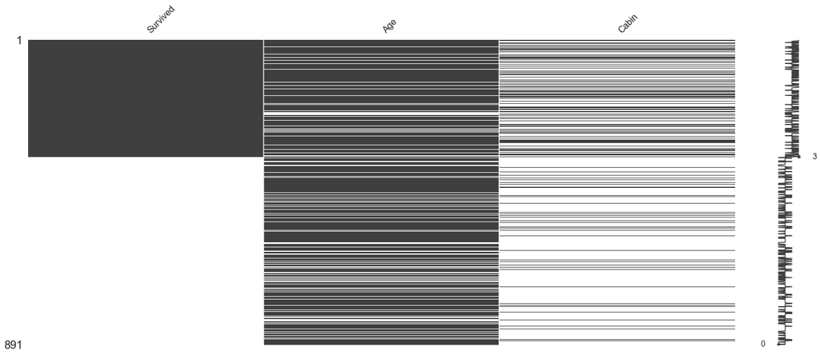

```python
temp = data[['Survived','Age','Cabin']].copy()
temp.loc[temp.Survived==0,'Survived'] = np.nan
temp = temp.sort_values(by='Survived')
print('사망자 Cabin 결측값 수: ',temp[temp.Survived!=1].Cabin.isnull().sum())
print('생존자 Cabin 결측값 수: ',temp[temp.Survived==1].Cabin.isnull().sum())
print('사망자 Age 결측값 수: ',temp[temp.Survived!=1].Age.isnull().sum())
print('생존자 Age 결측값 수: ',temp[temp.Survived==1].Age.isnull().sum())
mn.matrix(temp)
```

- Embarked의 경우 최빈값으로 대체한다.
- Fare의 경우 중앙값으로 대체한다.
- Age는 이후 Title과 Sex에 따라 중앙값으로 대체한다.

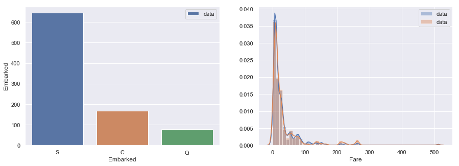

```python
f, ax = plt.subplots(1,2, figsize=(15,5))

sns.barplot(x='index', y='Embarked', data=data['Embarked'].value_counts().reset_index(), ax=ax[0], label='data')
ax[0].set_xlabel('Embarked')
ax[0].legend()

fare = data['Fare'].dropna()
fare_test = test['Fare'].dropna()
sns.distplot(fare, label='data', ax=ax[1])
sns.distplot(fare_test, label='data', ax=ax[1])
ax[1].legend()
```

```python
# Embarked : data
total_df.loc[:,'Embarked'] = total_df['Embarked'].apply(lambda x: total_df['Embarked'].mode()[0] if str(x)=='nan' else x)
# Fare : test
total_df.loc[:, 'Fare'] = total_df['Fare'].fillna(total_df['Fare'].median())

print('='*50)
print('Data missing value\n')
print(total_df.isnull().sum())
```

```
==================================================
Data missing value

Age             263
Cabin          1014
Embarked          0
Fare              0
Name              0
Parch             0
PassengerId       0
Pclass            0
Sex               0
SibSp             0
Survived          0
Ticket            0
split             0
dtype: int64
```

# EDA

## Sex

- 전체적인 인구는 남자가 더 많이 탑승했다.
- 생존은 여자가 많이 했다.

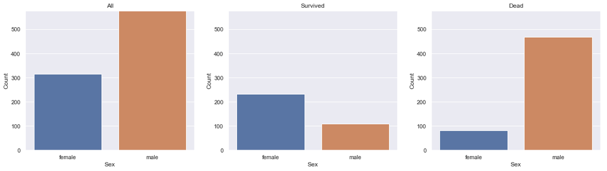

```python
f, ax = plt.subplots(1,3, figsize=(20,5))
temp = data.Sex.value_counts().reset_index()
temp1 = data[data.Survived==1].Sex.value_counts().reset_index()
temp0 = data[data.Survived==0].Sex.value_counts().reset_index()
temp_list = [temp, temp1, temp0]
title = ['All','Survived', 'Dead']
order = ['female','male']
for i in range(len(temp_list)):
    sns.barplot(x='index', y='Sex', data=temp_list[i], ax=ax[i], order=order)
    ax[i].set_title(title[i])
    ax[i].set_ylim([0,temp_list[0].Sex.max()])
    ax[i].set_ylabel('Count')
    ax[i].set_xlabel('Sex')
```

## Title

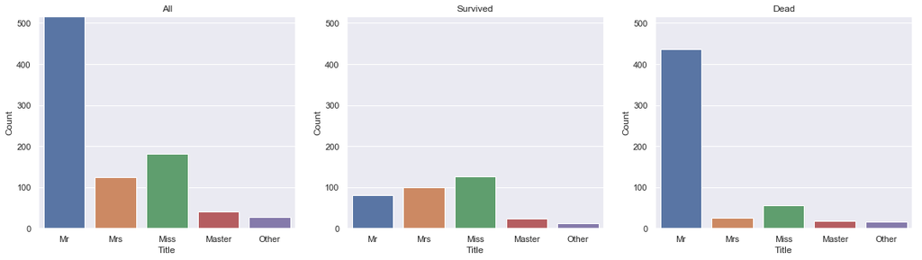

```python
Title = total_df.Name.apply(lambda x: x.split('.')[0].split(',')[1].strip())
major = Title.value_counts().iloc[:4]
total_df.loc[:,'Title'] = Title.apply(lambda x: 'Other' if x not in major.index else x)
major = total_df.Title.unique()

f, ax = plt.subplots(1,3, figsize=(20,5))
temp = total_df[total_df.split=='data'].Title.value_counts().reset_index()
temp1 = total_df[(total_df.split=='data') & (total_df.Survived==1)].Title.value_counts().reset_index()
temp0 = total_df[(total_df.split=='data') & (total_df.Survived==0)].Title.value_counts().reset_index()
temp_list = [temp, temp1, temp0]
title = ['All','Survived', 'Dead']
for i in range(len(temp_list)):
    sns.barplot(x='index', y='Title', data=temp_list[i], ax=ax[i], order=major)
    ax[i].set_title(title[i])
    ax[i].set_ylim([0,temp_list[0].Title.max()])
    ax[i].set_ylabel('Count')
    ax[i].set_xlabel('Title')
```

성별 Title에 따른 생존 여부 확인

남성

- Master인 경우 생존이 더 많고 다른 Mr나 Other의 경우 대부분이 사망

여성

- 대부분이 생존

[figure not shown]

```python
f, ax = plt.subplots(1,2, figsize=(10,5))

temp = total_df[total_df.split=='data'].groupby(['Sex','Title','Survived'])['PassengerId'].count().reset_index()
temp_male = temp[temp.Sex=='male']
temp_female = temp[temp.Sex=='female']
sns.barplot(x='Title', y='PassengerId', hue='Survived', data=temp_male, ax=ax[0])
ax[0].set_title('Title by Male')
sns.barplot(x='Title', y='PassengerId', hue='Survived', data=temp_female, ax=ax[1])
ax[1].set_title('Title by Male')
```

## Age

Missing value

- 나이는 위에서 구분한 Title과 성별에 따른 중앙값으로 대체한다.

Age

- 연령대비 생존여부의 차이는 크게 없어보인다

Age by Sex

- 성별 대비 연령대 차이도 크게 보이지 않는다

```python
# Missing value
for title in ['Mr','Master','Other']:
    group_age_median = total_df.loc[(total_df.Sex=='male')&(total_df.Title==title), 'Age'].median()
    total_df.loc[(total_df.Sex=='male')&(total_df.Title==title), 'Age'] = total_df.loc[(total_df.Sex=='male')&(total_df.Title==title), 'Age'].fillna(group_age_median)
    print('{} & {} median age: {}'.format(title,'male',group_age_median))

for title in ['Mrs','Miss','Other']:
    group_age_median = total_df.loc[(total_df.Sex=='female')&(total_df.Title==title), 'Age'].median()
    total_df.loc[(total_df.Sex=='female')&(total_df.Title==title), 'Age'] = total_df.loc[(total_df.Sex=='female')&(total_df.Title==title), 'Age'].fillna(group_age_median)
    print('{} & {} median age: {}'.format(title,'female',group_age_median))

total_df.isnull().sum()
```

```
Mr & male median age: 29.0
Master & male median age: 4.0
Other & male median age: 48.0
Mrs & female median age: 35.5
Miss & female median age: 22.0
Other & female median age: 30.5
```

```
Age               0
Cabin          1014
Embarked          0
Fare              0
Name              0
Parch             0
PassengerId       0
Pclass            0
Sex               0
SibSp             0
Survived          0
Ticket            0
split             0
Title             0
dtype: int64
```

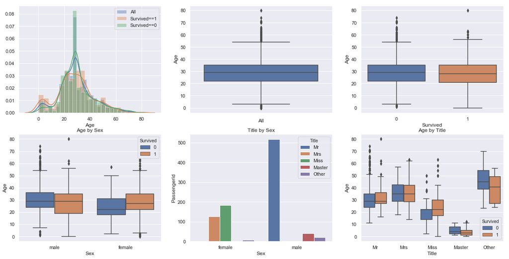

```python
total_df.loc[:,'Age'] = total_df.Age.astype(int)

f, ax = plt.subplots(2,3, figsize=(20,10))
sns.distplot(total_df[total_df.split=='data']['Age'],ax=ax[0,0], label='All')
sns.distplot(total_df[total_df.split=='data'][total_df[total_df.split=='data'].Survived==1]['Age'], ax=ax[0,0], label='Survived==1')
sns.distplot(total_df[total_df.split=='data'][total_df[total_df.split=='data'].Survived==0]['Age'], ax=ax[0,0], label='Survived==0')
sns.boxplot(total_df[total_df.split=='data']['Age'], ax=ax[0,1], orient='v')
sns.boxplot(x='Survived', y='Age', data=total_df[total_df.split=='data'], ax=ax[0,2])
ax[0,0].legend()
ax[0,1].set_xlabel('All')

sns.boxplot(x='Sex', y='Age', hue='Survived', data=total_df[total_df.split=='data'], ax=ax[1,0])
ax[1,0].set_title('Age by Sex')

temp = total_df[total_df.split=='data'].groupby(['Sex','Title'])['PassengerId'].count().reset_index()
sns.barplot(x='Sex', y='PassengerId', hue='Title', data=temp, ax=ax[1,1], hue_order=major)
ax[1,1].set_title('Title by Sex')

sns.boxplot(x='Title', y='Age', hue='Survived', data=total_df[total_df.split=='data'], ax=ax[1,2])
ax[1,2].set_title('Age by Title')
```

```python
total_df[(total_df.Age > 20) & (total_df.Title == 'Master')]
```

|  | Age | Cabin | Embarked | Fare | Name | Parch | PassengerId | Pclass | Sex | SibSp | Survived | Ticket | split | Title |
| --- | --- | --- | --- | --- | --- | --- | --- | --- | --- | --- | --- | --- | --- | --- |

```python
total_df = total_df.drop(total_df[(total_df.Age > 20) & (total_df.Title == 'Master')].index, axis=0)
print('test shape은 418 에서 변하면 안된다.:',total_df[total_df.split=='test'].shape)
```

```
test shape은 418 에서 변하면 안된다.: (418, 14)
```

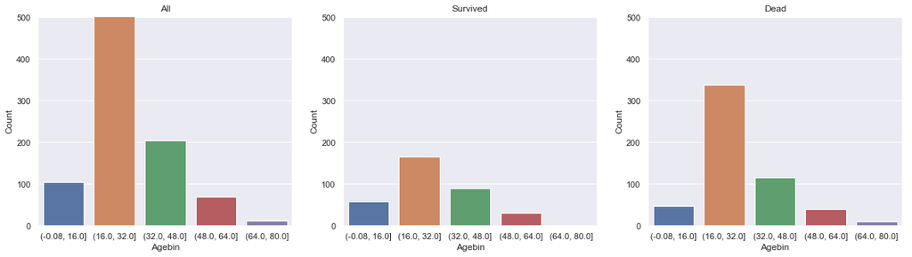

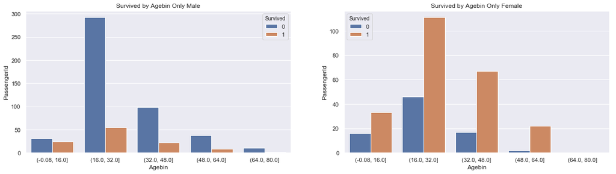

```python
total_df.loc[:,'Agebin'] = pd.cut(total_df.Age, 5)

f, ax = plt.subplots(1,3, figsize=(20,5))
temp = total_df[total_df.split=='data'].Agebin.value_counts().reset_index()
temp1 = total_df[(total_df.split=='data') & (total_df.Survived==1)].Agebin.value_counts().reset_index()
temp0 = total_df[(total_df.split=='data') & (total_df.Survived==0)].Agebin.value_counts().reset_index()
temp_list = [temp, temp1, temp0]
title = ['All','Survived', 'Dead']
for i in range(len(temp_list)):
    sns.barplot(x='index', y='Agebin', data=temp_list[i], ax=ax[i])
    ax[i].set_title(title[i])
    ax[i].set_ylim([0,temp_list[0].Agebin.max()])
    ax[i].set_ylabel('Count')
    ax[i].set_xlabel('Agebin')
plt.show()

f, ax = plt.subplots(1,2, figsize=(20,5))
temp = total_df[total_df.split=='data'].groupby(['Sex','Agebin','Survived'])['PassengerId'].count().reset_index()
temp_male = temp[temp.Sex=='male']
temp_female = temp[temp.Sex=='female']
sns.barplot(x='Agebin', y='PassengerId', hue='Survived', data=temp_male, ax=ax[0])
ax[0].set_title('Survived by Agebin Only Male')
sns.barplot(x='Agebin', y='PassengerId', hue='Survived', data=temp_female, ax=ax[1])
ax[1].set_title('Survived by Agebin Only Female')
```

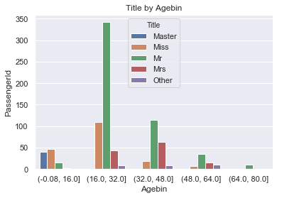

```python
temp = total_df[total_df.split=='data'].groupby(['Agebin','Title'])['PassengerId'].count().reset_index()
sns.barplot(x='Agebin', y='PassengerId', hue='Title', data=temp)
plt.title('Title by Agebin')
```

## SibSp

생존하지 못한 경우

- 형제자매, 배우자가 많은 경우가 있다.
- 형제자매, 배우자가 아예없는 비중이 생존한 경우에 비해 더 크다
- 형제자매, 배우자가 많거나 아예 없는 경우 사망할 확률이 크다

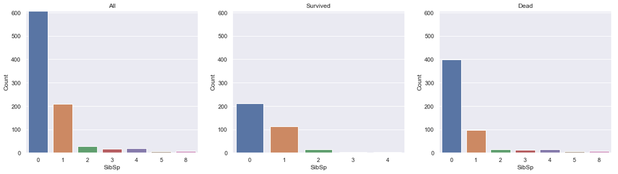

```python
f, ax = plt.subplots(1,3, figsize=(20,5))
temp = total_df[total_df.split=='data'].SibSp.value_counts().reset_index()
temp1 = total_df[total_df.split=='data'][total_df[total_df.split=='data'].Survived==1].SibSp.value_counts().reset_index()
temp0 = total_df[total_df.split=='data'][total_df[total_df.split=='data'].Survived==0].SibSp.value_counts().reset_index()
temp_list = [temp, temp1, temp0]
title = ['All','Survived', 'Dead']
for i in range(len(temp_list)):
    sns.barplot(x='index', y='SibSp', data=temp_list[i], ax=ax[i])
    ax[i].set_title(title[i])
    ax[i].set_ylim([0,temp_list[0].SibSp.max()])
    ax[i].set_ylabel('Count')
    ax[i].set_xlabel('SibSp')
```

## Parch

생존하지 못한 경우

- 부모, 자식이 많은 경우가 있다.
- 부모, 자식이 없는 경우가 생존한 경우보다 비중이 더 크다
- 부모 자식이 많거나 없으면 죽을 가능성이 높다.

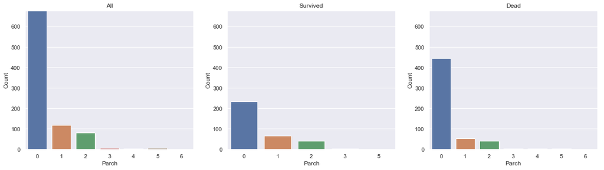

```python
f, ax = plt.subplots(1,3, figsize=(20,5))
temp = total_df[total_df.split=='data'].Parch.value_counts().reset_index()
temp1 = total_df[total_df.split=='data'][total_df[total_df.split=='data'].Survived==1].Parch.value_counts().reset_index()
temp0 = total_df[total_df.split=='data'][total_df[total_df.split=='data'].Survived==0].Parch.value_counts().reset_index()
temp_list = [temp, temp1, temp0]
title = ['All','Survived', 'Dead']
for i in range(len(temp_list)):
    sns.barplot(x='index', y='Parch', data=temp_list[i], ax=ax[i])
    ax[i].set_title(title[i])
    ax[i].set_ylim([0,temp_list[0].Parch.max()])
    ax[i].set_ylabel('Count')
    ax[i].set_xlabel('Parch')
```

## FamilySize (본인포함 가족 수)

- 위에서 본것과 마찬가지로 부양가족이 많거나 없을 수록 사망 가능성이 높다

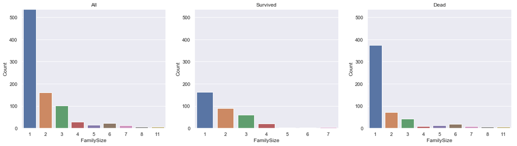

```python
total_df.loc[:, 'FamilySize'] = total_df['SibSp'] + total_df['Parch'] + 1

f, ax = plt.subplots(1,3, figsize=(20,5))
temp = total_df[total_df.split=='data'].FamilySize.value_counts().reset_index()
temp1 = total_df[(total_df.split=='data') & (total_df.Survived==1)].FamilySize.value_counts().reset_index()
temp0 = total_df[(total_df.split=='data') & (total_df.Survived==0)].FamilySize.value_counts().reset_index()
temp_list = [temp, temp1, temp0]
title = ['All','Survived', 'Dead']
for i in range(len(temp_list)):
    sns.barplot(x='index', y='FamilySize', data=temp_list[i], ax=ax[i])
    ax[i].set_title(title[i])
    ax[i].set_ylim([0,temp_list[0].FamilySize.max()])
    ax[i].set_ylabel('Count')
    ax[i].set_xlabel('FamilySize')
```

## IsAlone

- 혼자서 탑승한 경우가 더 많고
- 혼자인 경우 사망가능성이 높다

IsAlone by Sex

- 여성은 가족과 함께 온 경우가 더 많았고, 남성은 혼자 온 경우가 가족과 함께온 경우보다 두 배 이상 많았다

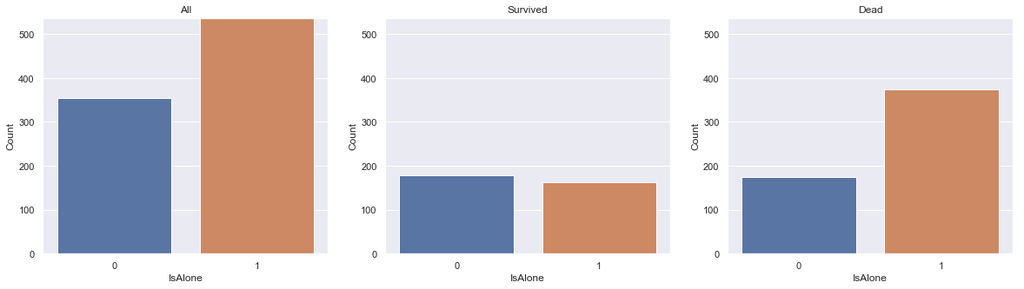

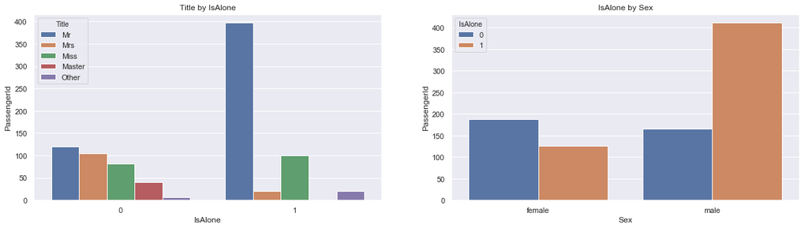

```python
total_df.loc[:, 'IsAlone'] = total_df.FamilySize.apply(lambda x: 0 if x > 1 else 1)

f, ax = plt.subplots(1,3, figsize=(20,5))
temp = total_df[total_df.split=='data'].IsAlone.value_counts().reset_index()
temp1 = total_df[(total_df.split=='data') & (total_df.Survived==1)].IsAlone.value_counts().reset_index()
temp0 = total_df[(total_df.split=='data') & (total_df.Survived==0)].IsAlone.value_counts().reset_index()
temp_list = [temp, temp1, temp0]
title = ['All','Survived', 'Dead']
for i in range(len(temp_list)):
    sns.barplot(x='index', y='IsAlone', data=temp_list[i], ax=ax[i])
    ax[i].set_title(title[i])
    ax[i].set_ylim([0,temp_list[0].IsAlone.max()])
    ax[i].set_ylabel('Count')
    ax[i].set_xlabel('IsAlone')
plt.show()

f, ax = plt.subplots(1,2, figsize=(20,5))

temp = total_df[total_df.split=='data'].groupby(['IsAlone','Title'])['PassengerId'].count().reset_index()
sns.barplot(x='IsAlone', y='PassengerId', hue='Title', data=temp, ax=ax[0], hue_order=major)
ax[0].set_title('Title by IsAlone')

temp = total_df[total_df.split=='data'].groupby(['Sex','IsAlone'])['PassengerId'].count().reset_index()
sns.barplot(x='Sex', y='PassengerId', hue='IsAlone', data=temp, ax=ax[1])
ax[1].set_title('IsAlone by Sex')
```

## Pclass

- 생존자의 경우, 3이 비교적 더 적다

Sex by Pclass

- 남녀 모두 3이 가장 많은 비중을 차지한다
- 남녀 가장 큰 차이가 나는 pclass는 3 이다. 두 배 이상 차이가 난다

Age by Pclass

- Pclass가 1이 가장 연령대가 높고 그 다음이 2 그 다음이 3이다.

Alone by Pclass

- 혼자인 경우 낮은 등급의 Pclass 비중이 혼자가 아닌 경우에 비해 더 크다

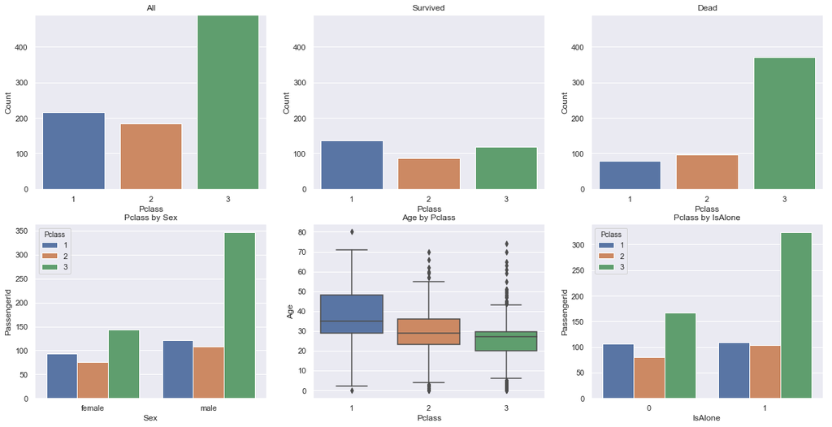

```python
f, ax = plt.subplots(2,3, figsize=(20,10))
temp = total_df[total_df.split=='data'].Pclass.value_counts().reset_index()
temp1 = total_df[(total_df.split=='data') & (total_df.Survived==1)].Pclass.value_counts().reset_index()
temp0 = total_df[(total_df.split=='data') & (total_df.Survived==0)].Pclass.value_counts().reset_index()
temp_list = [temp, temp1, temp0]
title = ['All','Survived', 'Dead']
for i in range(len(temp_list)):
    sns.barplot(x='index', y='Pclass', data=temp_list[i], ax=ax[0,i])
    ax[0,i].set_title(title[i])
    ax[0,i].set_ylim([0,temp_list[0].Pclass.max()])
    ax[0,i].set_ylabel('Count')
    ax[0,i].set_xlabel('Pclass')

temp = total_df[total_df.split=='data'].groupby(['Sex','Pclass'])['PassengerId'].count().reset_index()
sns.barplot(x='Sex', y='PassengerId', hue='Pclass', data=temp, ax=ax[1,0])
ax[1,0].set_title('Pclass by Sex')

sns.boxplot(x='Pclass', y='Age', data=total_df[total_df.split=='data'], ax=ax[1,1])
ax[1,1].set_title('Age by Pclass')

temp = total_df[total_df.split=='data'].groupby(['IsAlone','Pclass'])['PassengerId'].count().reset_index()
sns.barplot(x='IsAlone', y='PassengerId', hue='Pclass', data=temp, ax=ax[1,2])
ax[1,2].set_title('Pclass by IsAlone')
```

## Fare

Sex by Fare

- 여성이 남성에 비해 더 높은 표가격을 보인다.

Age by Fare

- 나이와 가격은 상관관계가 크게 없었다.

Alone by Fare

- 혼자인 경우 표가격이 혼자가 아닌경우에 비해 더 저렴하다.
- 혼자 온 경우는 남성이 대부분이였고 낮은 등급의 Pclass를 이용하기 때문이다

[figure not shown]

```python
fare = total_df[total_df.split=='data'][['PassengerId','Survived','Fare','Age','Sex','IsAlone']]
fare.IsAlone = fare.IsAlone.apply(lambda x: 'Alone' if x==1 else 'Not Alone')
fare.Fare = np.power(fare.Fare, 1/4)
f, ax = plt.subplots(2,3, figsize=(20,10))
sns.distplot(fare['Fare'],ax=ax[0,0], label='All')
sns.distplot(fare[fare.Survived==1]['Fare'], ax=ax[0,0], label='Survived==1')
sns.distplot(fare[fare.Survived==0]['Fare'], ax=ax[0,0], label='Survived==0')
sns.boxplot(fare['Fare'], ax=ax[0,1], orient='v')
sns.boxplot(x='Survived', y='Fare', data=fare, ax=ax[0,2])
ax[0,0].legend()
ax[0,1].set_xlabel('All')

sns.boxplot(x='Sex', y='Fare', data=fare, ax=ax[1,0])
ax[1,0].set_title('Fare by Sex')
sns.scatterplot(x='Age', y='Fare', data=fare, ax=ax[1,1])
ax[1,1].set_title('Age by Pclass : {}'.format(fare[['Fare','Age']].corr().round(3)))
sns.boxplot(x='IsAlone', y='Fare', data=fare, ax=ax[1,2])
ax[1,2].set_title('Pclass by IsAlone')
```

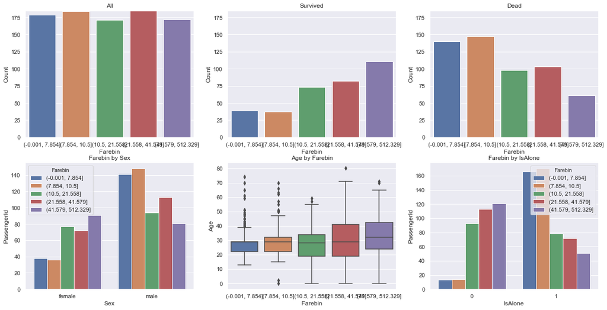

```python
total_df.loc[:,'Farebin'] = pd.qcut(total_df.Fare, 5)

f, ax = plt.subplots(2,3, figsize=(20,10))
temp = total_df[total_df.split=='data'].Farebin.value_counts().reset_index()
temp1 = total_df[(total_df.split=='data') & (total_df.Survived==1)].Farebin.value_counts().reset_index()
temp0 = total_df[(total_df.split=='data') & (total_df.Survived==0)].Farebin.value_counts().reset_index()
temp_list = [temp, temp1, temp0]
title = ['All','Survived', 'Dead']
for i in range(len(temp_list)):
    sns.barplot(x='index', y='Farebin', data=temp_list[i], ax=ax[0,i])
    ax[0,i].set_title(title[i])
    ax[0,i].set_ylim([0,temp_list[0].Farebin.max()])
    ax[0,i].set_ylabel('Count')
    ax[0,i].set_xlabel('Farebin')

temp = total_df[total_df.split=='data'].groupby(['Sex','Farebin'])['PassengerId'].count().reset_index()
sns.barplot(x='Sex', y='PassengerId', hue='Farebin', data=temp, ax=ax[1,0])
ax[1,0].set_title('Farebin by Sex')

sns.boxplot(x='Farebin', y='Age', data=total_df[total_df.split=='data'], ax=ax[1,1])
ax[1,1].set_title('Age by Farebin')

temp = total_df[total_df.split=='data'].groupby(['IsAlone','Farebin'])['PassengerId'].count().reset_index()
sns.barplot(x='IsAlone', y='PassengerId', hue='Farebin', data=temp, ax=ax[1,2])
ax[1,2].set_title('Farebin by IsAlone')
```

## Embarked

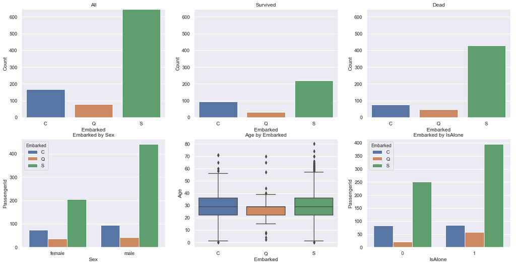

```python
f, ax = plt.subplots(2,3, figsize=(20,10))
order = ['C','Q', 'S']
temp = total_df[total_df.split=='data'].Embarked.value_counts().reset_index()
temp1 = total_df[(total_df.split=='data') & (total_df.Survived==1)].Embarked.value_counts().reset_index()
temp0 = total_df[(total_df.split=='data') & (total_df.Survived==0)].Embarked.value_counts().reset_index()
temp_list = [temp, temp1, temp0]
title = ['All','Survived', 'Dead']
for i in range(len(temp_list)):
    sns.barplot(x='index', y='Embarked', data=temp_list[i], ax=ax[0,i], order=order)
    ax[0,i].set_title(title[i])
    ax[0,i].set_ylim([0,temp_list[0].Embarked.max()])
    ax[0,i].set_ylabel('Count')
    ax[0,i].set_xlabel('Embarked')

temp = total_df[total_df.split=='data'].groupby(['Sex','Embarked'])['PassengerId'].count().reset_index()
sns.barplot(x='Sex', y='PassengerId', hue='Embarked', data=temp, ax=ax[1,0])
ax[1,0].set_title('Embarked by Sex')

sns.boxplot(x='Embarked', y='Age', data=total_df[total_df.split=='data'], ax=ax[1,1], order=order)
ax[1,1].set_title('Age by Embarked')

temp = total_df[total_df.split=='data'].groupby(['IsAlone','Embarked'])['PassengerId'].count().reset_index()
sns.barplot(x='IsAlone', y='PassengerId', hue='Embarked', data=temp, ax=ax[1,2])
ax[1,2].set_title('Embarked by IsAlone')
```

## Cabin

- 사망자의 경우 대부분이 결측값이다.

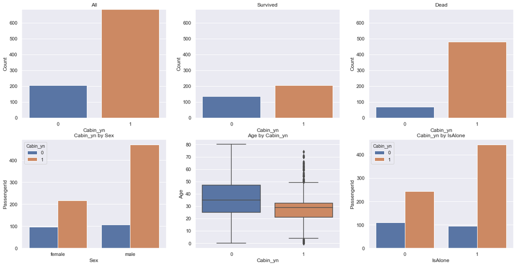

```python
total_df.loc[:, 'Cabin_yn'] = total_df.Cabin.isnull().astype(int)

f, ax = plt.subplots(2,3, figsize=(20,10))
temp = total_df[total_df.split=='data'].Cabin_yn.value_counts().reset_index()
temp1 = total_df[(total_df.split=='data') & (total_df.Survived==1)].Cabin_yn.value_counts().reset_index()
temp0 = total_df[(total_df.split=='data') & (total_df.Survived==0)].Cabin_yn.value_counts().reset_index()
temp_list = [temp, temp1, temp0]
title = ['All','Survived', 'Dead']
for i in range(len(temp_list)):
    sns.barplot(x='index', y='Cabin_yn', data=temp_list[i], ax=ax[0,i])
    ax[0,i].set_title(title[i])
    ax[0,i].set_ylim([0,temp_list[0].Cabin_yn.max()])
    ax[0,i].set_ylabel('Count')
    ax[0,i].set_xlabel('Cabin_yn')

temp = total_df[total_df.split=='data'].groupby(['Sex','Cabin_yn'])['PassengerId'].count().reset_index()
sns.barplot(x='Sex', y='PassengerId', hue='Cabin_yn', data=temp, ax=ax[1,0])
ax[1,0].set_title('Cabin_yn by Sex')

sns.boxplot(x='Cabin_yn', y='Age', data=total_df[total_df.split=='data'], ax=ax[1,1])
ax[1,1].set_title('Age by Cabin_yn')

temp = total_df[total_df.split=='data'].groupby(['IsAlone','Cabin_yn'])['PassengerId'].count().reset_index()
sns.barplot(x='IsAlone', y='PassengerId', hue='Cabin_yn', data=temp, ax=ax[1,2])
ax[1,2].set_title('Cabin_yn by IsAlone')
```

- 아래 링크에 각 Cabin의 이니셜에 따른 Pclass와 배의 위치에 대한 설명이 있다
- https://www.encyclopedia-titanica.org/cabins.html
- 'F' is the name of the deck, and 'G' or 'E' stands for the section under that deck.
- https://www.kaggle.com/c/titanic/discussion/22049#latest-175649

[figure not shown]

```python
total_df.Cabin = total_df.Cabin.fillna('unknown')

total_df.loc[:, 'Cabin_init'] = total_df.Cabin.apply(lambda x: x[0])

f, ax = plt.subplots(1,4, figsize=(20,5))
temp = total_df[total_df.split=='data'].groupby(['Pclass','Cabin_init'])['PassengerId'].count().reset_index()
sns.barplot(x='Pclass', y='PassengerId', hue='Cabin_init', data=temp, ax=ax[0])
ax[0].set_title('Pclass by Cabin_init')

temp = total_df[(total_df.split=='data') & (total_df.Cabin_init!='u')].groupby(['Pclass','Cabin_init'])['PassengerId'].count().reset_index()
sns.barplot(x='Pclass', y='PassengerId', hue='Cabin_init', data=temp, ax=ax[1])
ax[1].set_title('Pclass by Cabin_init without Unknown')

temp = total_df[total_df.split=='data'].groupby(['Survived','Cabin_init'])['PassengerId'].count().reset_index()
sns.barplot(x='Survived', y='PassengerId', hue='Cabin_init', data=temp, ax=ax[2])
ax[1].set_title('Survived by Cabin_init')

temp = total_df[(total_df.split=='data') & (total_df.Cabin_init!='u')].groupby(['Survived','Cabin_init'])['PassengerId'].count().reset_index()
sns.barplot(x='Survived', y='PassengerId', hue='Cabin_init', data=temp, ax=ax[3])
ax[1].set_title('Survived by Cabin_init without Unknown')
```

- data set의 Cabin init에서는 T가 있지만 Test set에서는 T가 없다. 그러므로 제외한다

```python
print(np.sort(list(total_df[total_df.split=='data'].Cabin_init.unique())))
print(np.sort(list(total_df[total_df.split=='test'].Cabin_init.unique())))
```

```
['A' 'B' 'C' 'D' 'E' 'F' 'G' 'T' 'u']
['A' 'B' 'C' 'D' 'E' 'F' 'G' 'u']
```

```python
total_df = total_df.drop(total_df[(total_df.split=='data') & (total_df.Cabin_init=='T')].index, axis=0)
print('test shape은 418 에서 변하면 안된다.:',total_df[total_df.split=='test'].shape)
```

```
test shape은 418 에서 변하면 안된다.: (418, 20)
```

```python
print(np.sort(list(total_df[total_df.split=='data'].Cabin_init.unique())))
print(np.sort(list(total_df[total_df.split=='test'].Cabin_init.unique())))
```

```
['A' 'B' 'C' 'D' 'E' 'F' 'G' 'u']
['A' 'B' 'C' 'D' 'E' 'F' 'G' 'u']
```

## Ticket

- 티켓 번호가 3인 경우 연령대가 가장 높다.
- 정확히 티켓번호가 무엇을 가르키는지는 모르지만 연령대와 연관이 있다.

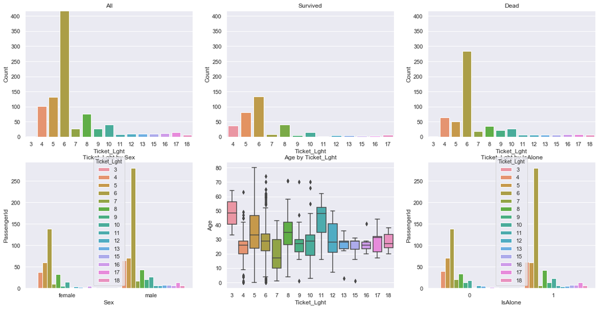

```python
total_df.loc[:,'Ticket_Lght'] = total_df.Ticket.apply(lambda x: len(x))

f, ax = plt.subplots(2,3, figsize=(20,10))
temp = total_df[total_df.split=='data'].Ticket_Lght.value_counts().reset_index()
temp1 = total_df[(total_df.split=='data') & (total_df.Survived==1)].Ticket_Lght.value_counts().reset_index()
temp0 = total_df[(total_df.split=='data') & (total_df.Survived==0)].Ticket_Lght.value_counts().reset_index()
temp_list = [temp, temp1, temp0]
title = ['All','Survived', 'Dead']
for i in range(len(temp_list)):
    sns.barplot(x='index', y='Ticket_Lght', data=temp_list[i], ax=ax[0,i])
    ax[0,i].set_title(title[i])
    ax[0,i].set_ylim([0,temp_list[0].Ticket_Lght.max()])
    ax[0,i].set_ylabel('Count')
    ax[0,i].set_xlabel('Ticket_Lght')

temp = total_df[total_df.split=='data'].groupby(['Sex','Ticket_Lght'])['PassengerId'].count().reset_index()
sns.barplot(x='Sex', y='PassengerId', hue='Ticket_Lght', data=temp, ax=ax[1,0])
ax[1,0].set_title('Ticket_Lght by Sex')

sns.boxplot(x='Ticket_Lght', y='Age', data=total_df[total_df.split=='data'], ax=ax[1,1])
ax[1,1].set_title('Age by Ticket_Lght')

temp = total_df[total_df.split=='data'].groupby(['IsAlone','Ticket_Lght'])['PassengerId'].count().reset_index()
sns.barplot(x='IsAlone', y='PassengerId', hue='Ticket_Lght', data=temp, ax=ax[1,2])
ax[1,2].set_title('Ticket_Lght by IsAlone')
```

Ticket이 영어와 숫자가 섞여있는 변수가 있어서 split한 후 split된 갯수에 어떤 차이가 있나 확인한 결과 크게 영향력은 없어 보인다.

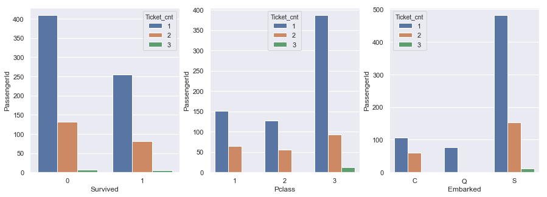

```python
total_df.loc[:, 'Ticket_cnt'] = total_df.Ticket.apply(lambda x: len(x.split()))

f, ax = plt.subplots(1,3, figsize=(15,5))

temp = total_df[total_df.split=='data'].groupby(['Survived','Ticket_cnt'])['PassengerId'].count().reset_index()
sns.barplot(x='Survived', y='PassengerId', hue='Ticket_cnt', data=temp, ax=ax[0])

temp = total_df[total_df.split=='data'].groupby(['Pclass','Ticket_cnt'])['PassengerId'].count().reset_index()
sns.barplot(x='Pclass', y='PassengerId', hue='Ticket_cnt', data=temp, ax=ax[1])

temp = total_df[total_df.split=='data'].groupby(['Embarked','Ticket_cnt'])['PassengerId'].count().reset_index()
sns.barplot(x='Embarked', y='PassengerId', hue='Ticket_cnt', data=temp, ax=ax[2])
```

# Split data

```python
data = total_df[total_df.split=='data']
test = total_df[total_df.split=='test']
print('data shape: ',data.shape)
print('test shape: ',test.shape)
```

```
data shape:  (890, 22)
test shape:  (418, 22)
```

# Correlation

- Categorical Variables들을 LabelEncoding하여 숫자로 변화합니다.
- Survived와 상관관계가 큰 변수는 순서대로 Sex, Pclass, Cabin_yn, Fare이다.

Sex

- 위에서 본 것과 마찬가지로 남성(1)일수록 사망(0)과 음의 상관관계가 있다라고 볼 수 있다.

Pclass

- 마찬가지로 Pclass가 (3)일수록 사망(0)과 음의 상관관계가 있다.

Cabin_yn

- Cabin이 결측값(1)인 경우 사망(0)과 음의 상관관계가 있다.

Fare bim

- 반대로 Fare가 클수록 생존(1)과 양의 상관관계가 있다.

```python
categorical_features = ['Pclass', 'Title', 'Sex', 'Embarked', 'Agebin', 'Farebin']
cor_df = data.copy()
for feature in categorical_features:
    encoder = LabelEncoder()
    encoder.fit(cor_df[feature])
    cor_df.loc[:,feature] = encoder.transform(cor_df[feature])
```

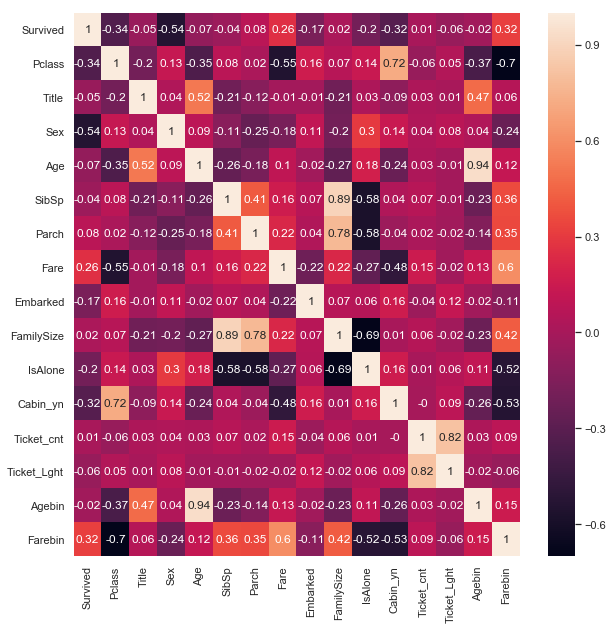

```python
features = ['Survived', 'Pclass', 'Title', 'Sex', 'Age', 'SibSp','Parch', 'Fare', 'Embarked', 'FamilySize',
            'IsAlone', 'Cabin_yn', 'Ticket_cnt', 'Ticket_Lght', 'Agebin', 'Farebin']
plt.figure(figsize=(10,10))
sns.heatmap(cor_df[features].corr().round(2), annot=True)
```

# Compare Train and Test

```python
num_features = ['Age', 'Fare']
cat_features = ['Pclass', 'Sex', 'SibSp', 'Parch', 'Embarked', 'IsAlone', 'Farebin', 'Title', 'Cabin_yn', 'Cabin_init']
```

```python
for f in num_features:
    results = stats.ttest_ind(data[f], test[f])
    print('Feature: {0}, statistics: {1:.4f}, p-value: {2:.4f}'.format(f,results[0], results[1]))

for f in cat_features:
    data_cat = data[f].value_counts().reset_index()
    data_cat.columns = ['index','data']
    test_cat = test[f].value_counts().reset_index()
    test_cat.columns = ['index','test']

    cat_df = pd.merge(data_cat, test_cat, on='index', how='inner')

    results = stats.chi2_contingency(cat_df.iloc[:,1:])
    print('Feature: {0}, statistics: {1:.4f}, p-value: {2:.4f}'.format(f,results[0], results[1]))
```

```
Feature: Age, statistics: -0.5000, p-value: 0.6172
Feature: Fare, statistics: -1.1001, p-value: 0.2715
Feature: Pclass, statistics: 1.0499, p-value: 0.5916
Feature: Sex, statistics: 0.1020, p-value: 0.7494
Feature: SibSp, statistics: 5.2550, p-value: 0.5115
Feature: Parch, statistics: 1.6773, p-value: 0.9469
Feature: Embarked, statistics: 8.4052, p-value: 0.0150
Feature: IsAlone, statistics: 0.0019, p-value: 0.9654
Feature: Farebin, statistics: 4.1944, p-value: 0.3803
Feature: Title, statistics: 4.5751, p-value: 0.3337
Feature: Cabin_yn, statistics: 0.1215, p-value: 0.7274
Feature: Cabin_init, statistics: 4.6566, p-value: 0.7018
```

Embarked는 왜 차이가나는가 싶었다 하니. 각 level별 Data와 Test에서 차지하는 비중은 크기 순은 갖으나 data의 S가 test보다 2배 이상 많다.

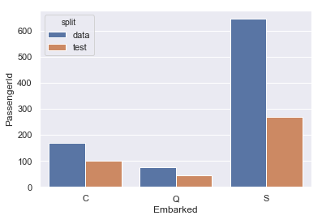

```python
sns.barplot(x='Embarked', y='PassengerId', hue='split', data=total_df.groupby(['split','Embarked'])['PassengerId'].count().reset_index())
```

# Feature Selection

```python
total_df.columns
```

```
Index(['Age', 'Cabin', 'Embarked', 'Fare', 'Name', 'Parch', 'PassengerId',
       'Pclass', 'Sex', 'SibSp', 'Survived', 'Ticket', 'split', 'Title',
       'Agebin', 'FamilySize', 'IsAlone', 'Farebin', 'Cabin_yn', 'Cabin_init',
       'Ticket_Lght', 'Ticket_cnt'],
      dtype='object')
```

```python
features = ['Pclass', 'Sex', 'Agebin', 'Farebin', 'Title', 'FamilySize', 'Cabin_init']
target = ['Survived']
x_data, y_data = data[features], data[target]
x_test = test[features]
```

## Label Encoding

```python
categorical_features = ['Agebin','Farebin']
for feature in categorical_features:
    encoder = LabelEncoder()
    x_data.loc[:,feature] = encoder.fit_transform(x_data[feature])
    x_test.loc[:,feature] = encoder.fit_transform(x_test[feature])
```

## Dummy variables

```python
def dummy_feature(df, variables):
    dummies = pd.DataFrame()
    for var in variables:
        dummy = pd.get_dummies(df[var], drop_first=True)
        dummies = pd.concat([dummies, dummy], axis=1)
        df = df.drop(var, axis=1)
    df = pd.concat([df, dummies], axis=1)
    return df
```

```python
categorical_features = ['Sex','Title', 'Cabin_init']
x_data = dummy_feature(x_data, categorical_features)
x_test = dummy_feature(x_test, categorical_features)
```

```python
x_data.columns
```

```
Index(['Pclass', 'Agebin', 'Farebin', 'FamilySize', 'male', 'Miss', 'Mr',
       'Mrs', 'Other', 'B', 'C', 'D', 'E', 'F', 'G', 'u'],
      dtype='object')
```

# Models

## Configuration

```python
config = {
    "seed":13026035,
    "k_folds":5,
    "early_stopping_rounds":100
}
```

## Logistic Regression

```python
# num_features = ['Agebin','Fare','FamilySize']
```

```python
lr_params = {
    'random_state':config['seed'],
    'max_iter':10000
}
```

```python
folds = KFold(n_splits=config['k_folds'], random_state=config['seed'], shuffle=True)

lr_auc_list = list()
lr_acc_list = list()
lr_S_prediction = np.zeros(len(x_data))
lr_prediction = np.zeros(len(x_test))
lr_feature_importance_df = pd.DataFrame()
for fold, (train_idx, valid_idx) in enumerate(folds.split(X=x_data, y=y_data)):
    x_train, y_train = x_data.iloc[train_idx, :], y_data.iloc[train_idx]
    x_valid, y_valid = x_data.iloc[valid_idx, :], y_data.iloc[valid_idx]

#     x_test_lr = x_test.copy()
#     scaler = StandardScaler()
#     scaler.fit(x_train[num_features])
#     x_train[num_features] = scaler.transform(x_train[num_features])
#     x_valid[num_features] = scaler.transform(x_valid[num_features])
#     x_test_lr[num_features] = scaler.transform(x_test_lr[num_features])

    model = LogisticRegression(**lr_params)
    model.fit(X=x_train, y=y_train)

    prob = model.predict_proba(x_valid)[:,1]
    test_prob = model.predict_proba(x_test)[:,1]

    auc = metrics.roc_auc_score(y_true=y_valid, y_score=prob)
    lr_auc_list.append(auc)
    pred = [1 if p > 0.5 else 0 for p in prob]
    acc = metrics.accuracy_score(y_true=y_valid, y_pred=pred)
    lr_acc_list.append(acc)

    lr_S_prediction[valid_idx] = prob
    lr_prediction += test_prob / folds.n_splits

    fold_importance_df = pd.DataFrame()
    coef_dict = dict()
    for i in zip(x_data.columns, model.coef_[0]):
        coef_dict[i[0]] = i[1]
    coef_dict['INTERCEPT'] = model.intercept_[0]
    fold_importance_df["feature"] = list(coef_dict.keys())
    fold_importance_df["importance"] = list(coef_dict.values())
    fold_importance_df["fold"] = fold + 1
    lr_feature_importance_df = pd.concat([lr_feature_importance_df, fold_importance_df], axis=0)

    print("{} fold's AUC: {}".format(fold+1, auc))
    print("{} fold's ACC: {}".format(fold+1, acc))

print('='*100)
print('AUC_LIST')
print(lr_auc_list)

print('-'*100)
print('Mean AUC: {}'.format(np.mean(lr_auc_list)))

print('='*100)
print('ACC_LIST')
print(lr_acc_list)

print('-'*100)
print('Mean ACC: {}'.format(np.mean(lr_acc_list)))
```

```
1 fold's AUC: 0.8319264805990471
1 fold's ACC: 0.7865168539325843
2 fold's AUC: 0.8214611872146118
2 fold's ACC: 0.7584269662921348
3 fold's AUC: 0.8641534391534392
3 fold's ACC: 0.8258426966292135
4 fold's AUC: 0.9085397316821465
4 fold's ACC: 0.8370786516853933
5 fold's AUC: 0.9179597701149426
5 fold's ACC: 0.8426966292134831
====================================================================================================
AUC_LIST
[0.8319264805990471, 0.8214611872146118, 0.8641534391534392, 0.9085397316821465, 0.9179597701149426]
----------------------------------------------------------------------------------------------------
Mean AUC: 0.8688081217528374
====================================================================================================
ACC_LIST
[0.7865168539325843, 0.7584269662921348, 0.8258426966292135, 0.8370786516853933, 0.8426966292134831]
----------------------------------------------------------------------------------------------------
Mean ACC: 0.8101123595505617
```

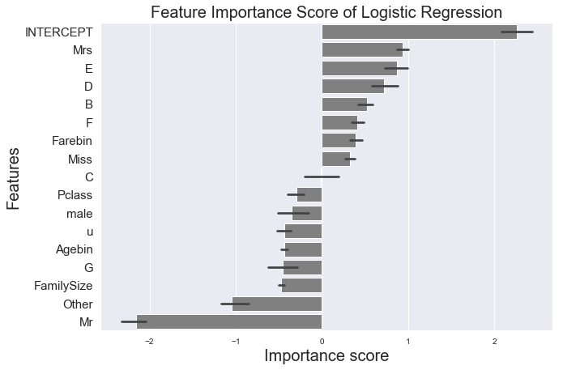

```python
plt.figure(figsize=(10,7))
order_features = lr_feature_importance_df.groupby('feature').mean().sort_values(by='importance', ascending=False).index
sns.barplot(x='importance' ,y='feature', data=lr_feature_importance_df.sort_values(by='importance', ascending=False), order=order_features, color='gray')
plt.xlabel('Importance score', size=20)
plt.ylabel('Features', size=20)
plt.title('Feature Importance Score of Logistic Regression', size=20)
plt.yticks(size=15)
plt.xticks(size=10)
```

## Random Forest

```python
rf_params = {
    'criterion' : 'entropy',
    'max_depth' : 6,
    'n_estimators' : 500,
    'oob_score' : True,
    'n_jobs': 20,
    'random_state' : config['seed']
}
```

```python
folds = KFold(n_splits=config['k_folds'], random_state=config['seed'], shuffle=True)

rf_auc_list = list()
rf_acc_list = list()
rf_S_prediction = np.zeros(len(x_data))
rf_prediction = np.zeros(len(x_test))
rf_feature_importance_df = pd.DataFrame()
for fold, (train_idx, valid_idx) in enumerate(folds.split(X=x_data, y=y_data)):
    x_train, y_train = x_data.iloc[train_idx, :], y_data.iloc[train_idx]
    x_valid, y_valid = x_data.iloc[valid_idx, :], y_data.iloc[valid_idx]

    model = RFC(**rf_params)
    model.fit(x_train, y_train)

    prob = model.predict_proba(x_valid)[:,1]
    test_prob = model.predict_proba(x_test)[:,1]

    auc = metrics.roc_auc_score(y_true=y_valid, y_score=prob)
    rf_auc_list.append(auc)
    pred = [1 if p > 0.5 else 0 for p in prob]
    acc = metrics.accuracy_score(y_true=y_valid, y_pred=pred)
    rf_acc_list.append(acc)

    rf_S_prediction[valid_idx] = prob
    rf_prediction += test_prob / folds.n_splits

    fold_importance_df = pd.DataFrame()
    fold_importance_df["feature"] = x_data.columns
    fold_importance_df["importance"] = model.feature_importances_
    fold_importance_df["fold"] = fold + 1
    rf_feature_importance_df = pd.concat([rf_feature_importance_df, fold_importance_df], axis=0)

    print("{} fold's AUC: {}".format(fold+1, auc))
    print("{} fold's ACC: {}".format(fold+1, acc))

print('='*100)
print('AUC_list')
print(rf_auc_list)

print('-'*100)
print('Mean AUC: {}'.format(np.mean(rf_auc_list)))

print('='*100)
print('ACC_list')
print(rf_acc_list)

print('-'*100)
print('Mean ACC: {}'.format(np.mean(rf_acc_list)))
```

```
1 fold's AUC: 0.8587474472430225
1 fold's ACC: 0.8202247191011236
2 fold's AUC: 0.8084148727984346
2 fold's ACC: 0.7921348314606742
3 fold's AUC: 0.8580687830687831
3 fold's ACC: 0.8258426966292135
4 fold's AUC: 0.9060887512899897
4 fold's ACC: 0.8426966292134831
5 fold's AUC: 0.9053160919540231
5 fold's ACC: 0.8595505617977528
====================================================================================================
AUC_list
[0.8587474472430225, 0.8084148727984346, 0.8580687830687831, 0.9060887512899897, 0.9053160919540231]
----------------------------------------------------------------------------------------------------
Mean AUC: 0.8673271892708506
====================================================================================================
ACC_list
[0.8202247191011236, 0.7921348314606742, 0.8258426966292135, 0.8426966292134831, 0.8595505617977528]
----------------------------------------------------------------------------------------------------
Mean ACC: 0.8280898876404494
```

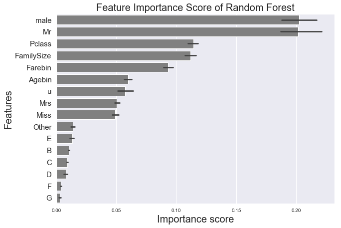

```python
plt.figure(figsize=(10,7))
order_features = rf_feature_importance_df.groupby('feature').mean().sort_values(by='importance', ascending=False).index
sns.barplot(x='importance' ,y='feature', data=rf_feature_importance_df.sort_values(by='importance', ascending=False), order=order_features, color='gray')
plt.xlabel('Importance score', size=20)
plt.ylabel('Features', size=20)
plt.title('Feature Importance Score of Random Forest', size=20)
plt.yticks(size=15)
plt.xticks(size=10)
```

## XGboost

```python
xgb_params = {
    "learning_rate": 0.1,
    "n_estimators": 10000,
    "max_depth": 3,
    "min_child_weight": 3,
    "subsample": 0.8,
    "colsample_bytree": 1.0,
    "colsample_bylevel": 1.0,
    "alpha": 0,
    "lambda": 1,
    "objective": "gpu:binary:logistic",
    "tree_method": "gpu_hist",
    "predictor": "gpu_predictor"
}
```

```python
folds = KFold(n_splits=config['k_folds'], random_state=config['seed'], shuffle=True)

xgb_auc_list = list()
xgb_acc_list = list()
xgb_S_prediction = np.zeros(len(x_data))
xgb_prediction = np.zeros(len(x_test))
xgb_feature_importance_df = pd.DataFrame()

for fold, (train_idx, valid_idx) in enumerate(folds.split(X=x_data, y=y_data)):
    x_train, y_train = x_data.iloc[train_idx,:], y_data.iloc[train_idx]
    x_valid, y_valid = x_data.iloc[valid_idx,:], y_data.iloc[valid_idx]
    xgb_model = xgb.XGBClassifier(**xgb_params)
    xgb_model.fit(x_train, y_train,
              eval_set=[(x_valid, y_valid)],
              eval_metric="auc",
              early_stopping_rounds=config['early_stopping_rounds'],
              verbose=False)

    prob = xgb_model.predict_proba(x_valid, ntree_limit=xgb_model.best_iteration)[:,1]
    test_prob = xgb_model.predict_proba(x_test, ntree_limit=xgb_model.best_iteration)[:,1]

    auc = metrics.roc_auc_score(y_true=y_valid, y_score=prob)
    pred = [1 if p > 0.5 else 0 for p in prob]
    acc = metrics.accuracy_score(y_true=y_valid, y_pred=pred)
    xgb_auc_list.append(auc)
    xgb_acc_list.append(acc)

    xgb_S_prediction[valid_idx] = prob
    xgb_prediction += test_prob / folds.n_splits

    fold_importance_df = pd.DataFrame()
    fold_importance_df["feature"] = list(xgb_model.get_booster().get_score(importance_type='gain').keys())
    fold_importance_df["importance"] = list(xgb_model.get_booster().get_score(importance_type='gain').values())
    fold_importance_df["fold"] = fold + 1
    xgb_feature_importance_df = pd.concat([xgb_feature_importance_df, fold_importance_df], axis=0)

    print("{} fold's AUC: {}".format(fold+1, auc))
    print("{} fold's ACC: {}".format(fold+1, acc))

print('='*100)
print('AUC_list')
print(xgb_auc_list)

print('-'*100)
print('Mean AUC: {}'.format(np.mean(xgb_auc_list)))

print('='*100)
print('ACC_list')
print(xgb_acc_list)

print('-'*100)
print('Mean ACC: {}'.format(np.mean(xgb_acc_list)))
```

```
[01:29:46] WARNING: C:/dev/libs/xgboost/src/objective/regression_obj.cu:170: gpu:binary:logistic is now deprecated, use binary:logistic instead.
1 fold's AUC: 0.863512593601089
1 fold's ACC: 0.797752808988764
[01:29:46] WARNING: C:/dev/libs/xgboost/src/objective/regression_obj.cu:170: gpu:binary:logistic is now deprecated, use binary:logistic instead.
2 fold's AUC: 0.8275277234181344
2 fold's ACC: 0.7921348314606742
[01:29:46] WARNING: C:/dev/libs/xgboost/src/objective/regression_obj.cu:170: gpu:binary:logistic is now deprecated, use binary:logistic instead.
3 fold's AUC: 0.864021164021164
3 fold's ACC: 0.8202247191011236
[01:29:47] WARNING: C:/dev/libs/xgboost/src/objective/regression_obj.cu:170: gpu:binary:logistic is now deprecated, use binary:logistic instead.
4 fold's AUC: 0.9017672858617131
4 fold's ACC: 0.8426966292134831
[01:29:47] WARNING: C:/dev/libs/xgboost/src/objective/regression_obj.cu:170: gpu:binary:logistic is now deprecated, use binary:logistic instead.
5 fold's AUC: 0.9111350574712643
5 fold's ACC: 0.8651685393258427
====================================================================================================
AUC_list
[0.863512593601089, 0.8275277234181344, 0.864021164021164, 0.9017672858617131, 0.9111350574712643]
----------------------------------------------------------------------------------------------------
Mean AUC: 0.873592764874673
====================================================================================================
ACC_list
[0.797752808988764, 0.7921348314606742, 0.8202247191011236, 0.8426966292134831, 0.8651685393258427]
----------------------------------------------------------------------------------------------------
Mean ACC: 0.8235955056179775
```

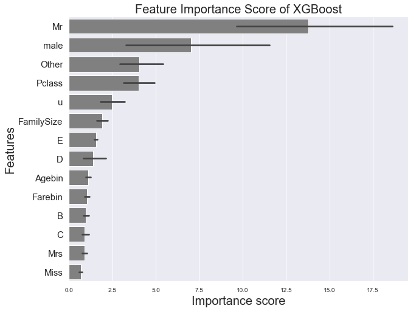

```python
plt.figure(figsize=(10,8))
order_features = xgb_feature_importance_df.groupby('feature').mean().sort_values(by='importance', ascending=False).index
sns.barplot(x='importance' ,y='feature', data=xgb_feature_importance_df.sort_values(by='importance', ascending=False), order=order_features , color='gray')
plt.xlabel('Importance score', size=20)
plt.ylabel('Features', size=20)
plt.title('Feature Importance Score of XGBoost', size=20)
plt.yticks(size=15)
plt.xticks(size=10)
```

## LightGBM

```python
lgb_params = {
    'learning_rate': 0.1,
    'n_estimators': 10000,
    'max_depth': 3,
    'num_leaves': 4,
    'subsample': 0.8,
    'colsample_bytree': 1.0,
    'feature_fraction': 1.0,
    'bagging_fraction': 1.0,
    'reg_alpha': 0,
    'reg_lambda': 1,
    'min_child_weight': 5,
    'metric': 'auc',
    'boosting_type': 'gbdt',
    'objective': 'regression',
}
```

```python
folds = KFold(n_splits=config['k_folds'], random_state=config['seed'], shuffle=True)

lgb_auc_list = list()
lgb_acc_list = list()
lgb_S_prediction = np.zeros(len(x_data))
lgb_prediction = np.zeros(len(x_test))
lgb_f_score_df = pd.DataFrame()

for fold, (train_idx, valid_idx) in enumerate(folds.split(X=x_data, y=y_data)):
    x_train, y_train = x_data.iloc[train_idx,:], y_data.iloc[train_idx]
    x_valid, y_valid = x_data.iloc[valid_idx,:], y_data.iloc[valid_idx]
    lgb_model = lgb.LGBMClassifier(**lgb_params)
    lgb_model.fit(x_train, y_train,
                  eval_set=[(x_train, y_train), (x_valid, y_valid)],
                  early_stopping_rounds=config['early_stopping_rounds'],
                  verbose=False)

    prob = lgb_model.predict_proba(x_valid, num_iteration=lgb_model.best_iteration_)[:,1]
    test_prob = lgb_model.predict_proba(x_test, num_iteration=lgb_model.best_iteration_)[:,1]

    auc = metrics.roc_auc_score(y_true=y_valid, y_score=prob)
    pred = [1 if p > 0.5 else 0 for p in prob]
    acc = metrics.accuracy_score(y_true=y_valid, y_pred=pred)
    lgb_auc_list.append(auc)
    lgb_acc_list.append(acc)
    lgb_S_prediction[valid_idx] = prob
    lgb_prediction += test_prob / folds.n_splits

    fold_f_score_df = pd.DataFrame()
    fold_f_score_df["feature"] = x_data.columns
    fold_f_score_df["f"] = lgb_model.feature_importances_
    fold_f_score_df["fold"] = fold + 1
    lgb_f_score_df = pd.concat([lgb_f_score_df, fold_f_score_df], axis=0)

    print("{} fold's AUC: {}".format(fold+1, auc))
    print("{} fold's ACC: {}".format(fold+1, acc))

print('='*100)
print('AUC_list')
print(lgb_auc_list)

print('-'*100)
print('Mean AUC: {}'.format(np.mean(lgb_auc_list)))

print('='*100)
print('ACC_list')
print(lgb_acc_list)

print('-'*100)
print('Mean ACC: {}'.format(np.mean(lgb_acc_list)))
```

```
1 fold's AUC: 0.8696392103471748
1 fold's ACC: 0.8146067415730337
2 fold's AUC: 0.8417482061317678
2 fold's ACC: 0.8089887640449438
3 fold's AUC: 0.8754629629629629
3 fold's ACC: 0.8033707865168539
4 fold's AUC: 0.9090557275541795
4 fold's ACC: 0.8539325842696629
5 fold's AUC: 0.9163074712643678
5 fold's ACC: 0.8595505617977528
====================================================================================================
AUC_list
[0.8696392103471748, 0.8417482061317678, 0.8754629629629629, 0.9090557275541795, 0.9163074712643678]
----------------------------------------------------------------------------------------------------
Mean AUC: 0.8824427156520906
====================================================================================================
ACC_list
[0.8146067415730337, 0.8089887640449438, 0.8033707865168539, 0.8539325842696629, 0.8595505617977528]
----------------------------------------------------------------------------------------------------
Mean ACC: 0.8280898876404494
```

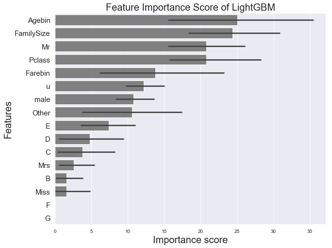

```python
plt.figure(figsize=(10,8))
order_features = lgb_f_score_df.groupby('feature').mean().sort_values(by='f', ascending=False).index
sns.barplot(x='f' ,y='feature', data=lgb_f_score_df.sort_values(by='f', ascending=False), order=order_features , color='gray')
plt.xlabel('Importance score', size=20)
plt.ylabel('Features', size=20)
plt.title('Feature Importance Score of LightGBM', size=20)
plt.yticks(size=15)
plt.xticks(size=10)
```

# Esemble

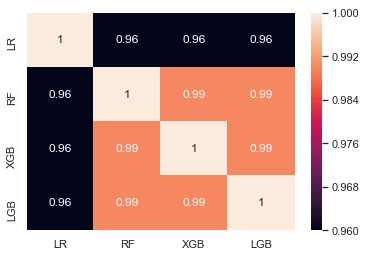

```python
probs = pd.DataFrame({'LR':lr_prediction, 'RF':rf_prediction, 'XGB':xgb_prediction, 'LGB':lgb_prediction})
sns.heatmap(probs.corr().round(2), annot=True)
```

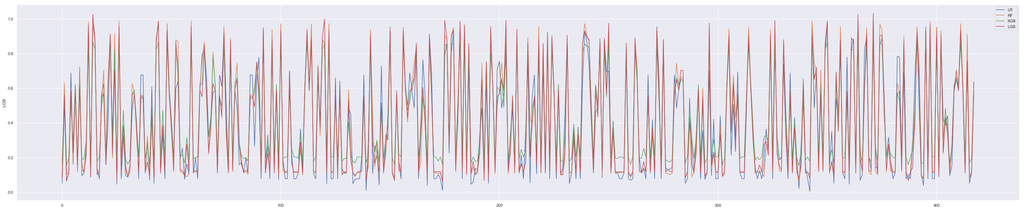

```python
plt.figure(figsize=(50,10))
sns.lineplot(x=np.arange(probs.shape[0]), y=probs.LR, label='LR')
sns.lineplot(x=np.arange(probs.shape[0]), y=probs.RF, label='RF')
sns.lineplot(x=np.arange(probs.shape[0]), y=probs.XGB, label='XGB')
sns.lineplot(x=np.arange(probs.shape[0]), y=probs.LGB, label='LGB')
```

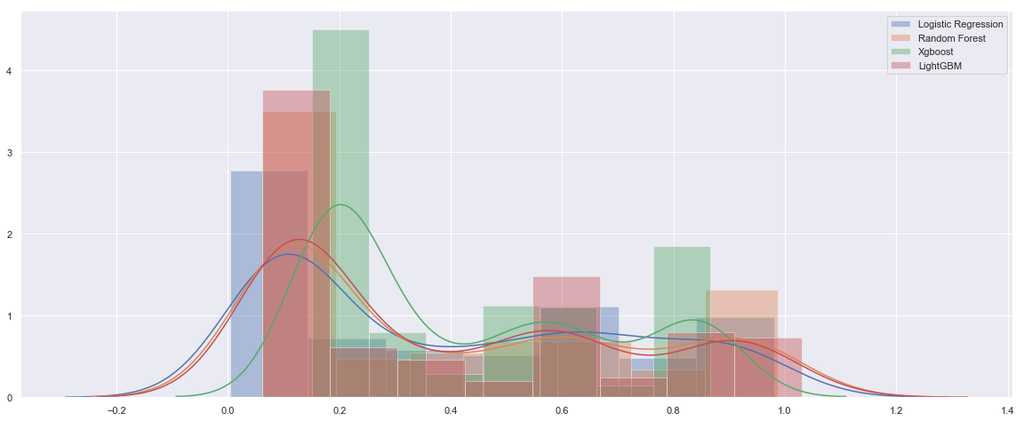

```python
plt.figure(figsize=(20,8))
sns.distplot(lr_prediction, label='Logistic Regression')
sns.distplot(rf_prediction, label='Random Forest')
sns.distplot(xgb_prediction, label='Xgboost')
sns.distplot(lgb_prediction, label='LightGBM')
plt.legend()
```

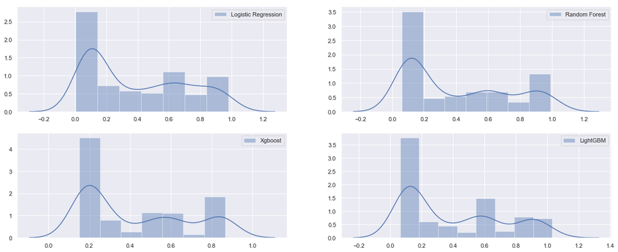

```python
f, ax = plt.subplots(2,2,figsize=(20,8))
sns.distplot(lr_prediction, label='Logistic Regression', ax=ax[0,0])
sns.distplot(rf_prediction, label='Random Forest', ax=ax[0,1])
sns.distplot(xgb_prediction, label='Xgboost', ax=ax[1,0])
sns.distplot(lgb_prediction, label='LightGBM', ax=ax[1,1])
ax[0,0].legend()
ax[0,1].legend()
ax[1,0].legend()
ax[1,1].legend()
```

```python
en = probs.apply(lambda x: np.mean(x), axis=1)
en_xgb_lr = probs[['LR','XGB']].apply(lambda x: np.mean(x), axis=1)
en_lgb_lr = probs[['LR','LGB']].apply(lambda x: np.mean(x), axis=1)
en_rf_lr = probs[['LR','RF']].apply(lambda x: np.mean(x), axis=1)
en_rf_xgb = probs[['XGB','RF']].apply(lambda x: np.mean(x), axis=1)
en_rf_lgb = probs[['LGB','RF']].apply(lambda x: np.mean(x), axis=1)
en_xgb_lgb = probs[['LGB','XGB']].apply(lambda x: np.mean(x), axis=1)
en_xgb_lgb_lr = probs[['LGB','XGB','LR']].apply(lambda x: np.mean(x), axis=1)
en_xgb_rf_lr = probs[['RF','XGB','LR']].apply(lambda x: np.mean(x), axis=1)
en_rf_lgb_lr = probs[['LGB','RF','LR']].apply(lambda x: np.mean(x), axis=1)
en_xgb_lgb_rf = probs[['LGB','XGB','RF']].apply(lambda x: np.mean(x), axis=1)
en_pred = en.apply(lambda x: 1 if x > 0.5 else 0)
xgb_pred = [1 if p > 0.5 else 0 for p in xgb_prediction]
lr_pred = [1 if p > 0.5 else 0 for p in lr_prediction]
rf_pred = [1 if p > 0.5 else 0 for p in rf_prediction]
lgb_pred = [1 if p > 0.5 else 0 for p in lgb_prediction]

preds = pd.DataFrame({'LR':lr_pred,'RF':rf_pred, 'XGB':xgb_pred,'LGB':lgb_pred, 'EN':en_pred})
en_major = preds.apply(lambda x: 1 if np.sum(x) > 2 else 0, axis=1)
```

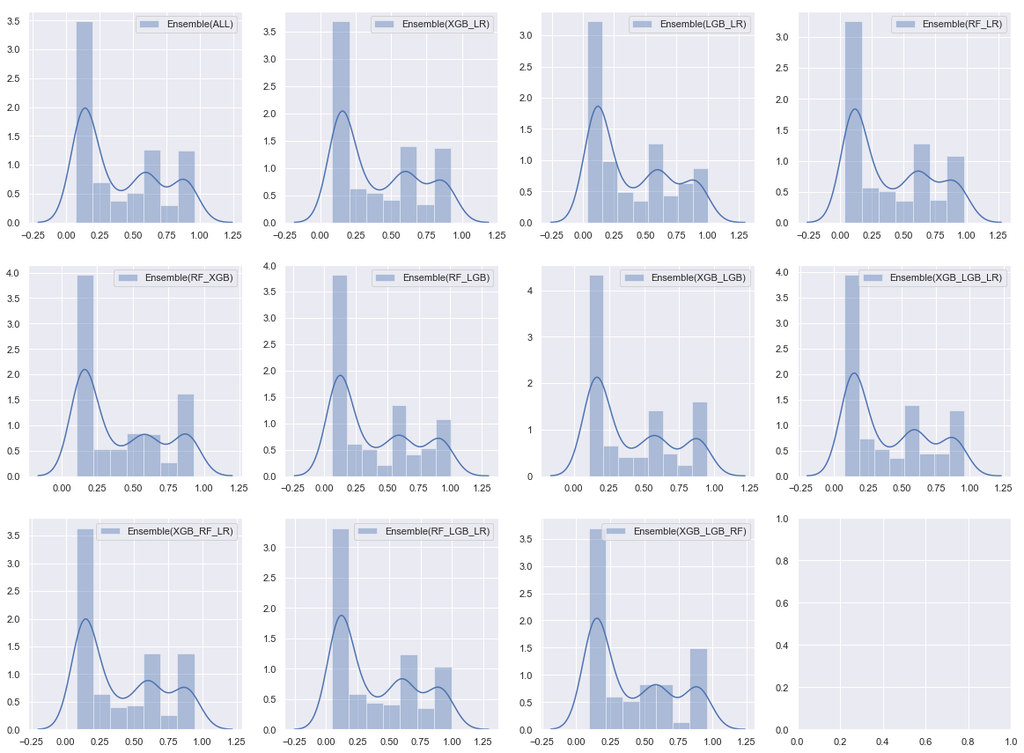

```python
en_probs = [en, en_xgb_lr, en_lgb_lr, en_rf_lr, en_rf_xgb, en_rf_lgb, en_xgb_lgb,
            en_xgb_lgb_lr, en_xgb_rf_lr,en_rf_lgb_lr, en_xgb_lgb_rf]
en_names = ['Ensemble(ALL)', 'Ensemble(XGB_LR)', 'Ensemble(LGB_LR)', 'Ensemble(RF_LR)',
        'Ensemble(RF_XGB)', 'Ensemble(RF_LGB)', 'Ensemble(XGB_LGB)', 'Ensemble(XGB_LGB_LR)',
        'Ensemble(XGB_RF_LR)', 'Ensemble(RF_LGB_LR)', 'Ensemble(XGB_LGB_RF)']
f, ax = plt.subplots(3,4, figsize=(20,15))
for i in range(len(en_probs)):
    sns.distplot(en_probs[i], label=en_names[i], ax=ax[i//4,i%4])
    ax[i//4,i%4].legend()
```

## Rank Ensemble

```python
def rank_ensemble(probs):
    en_probs = probs.copy()
    for col in probs.columns:
        en_probs = en_probs.sort_values(by=col)
        en_probs.loc[:,col] = np.arange(1,en_probs.shape[0]+1)
    en_probs = en_probs.sort_index()
    en_probs = probs.apply(lambda x: np.mean(x), axis=1)
    max_ = max(en_probs)
    min_ = min(en_probs)
    en_probs = en_probs.apply(lambda x: (x-min_)/(max_-min_))
    return en_probs
```

```python
en_rank = rank_ensemble(probs)
en_rank_xgb_lr = rank_ensemble(probs[['LR','XGB']])
en_rank_lgb_lr = rank_ensemble(probs[['LR','LGB']])
en_rank_rf_lr = rank_ensemble(probs[['LR','RF']])
en_rank_rf_xgb = rank_ensemble(probs[['XGB','RF']])
en_rank_rf_lgb = rank_ensemble(probs[['LGB','RF']])
en_rank_xgb_lgb = rank_ensemble(probs[['LGB','XGB']])
en_rank_xgb_lgb_lr = rank_ensemble(probs[['LGB','XGB','LR']])
en_rank_xgb_rf_lr = rank_ensemble(probs[['RF','XGB','LR']])
en_rank_rf_lgb_lr = rank_ensemble(probs[['LGB','RF','LR']])
en_rank_xgb_lgb_rf = rank_ensemble(probs[['LGB','XGB','RF']])
```

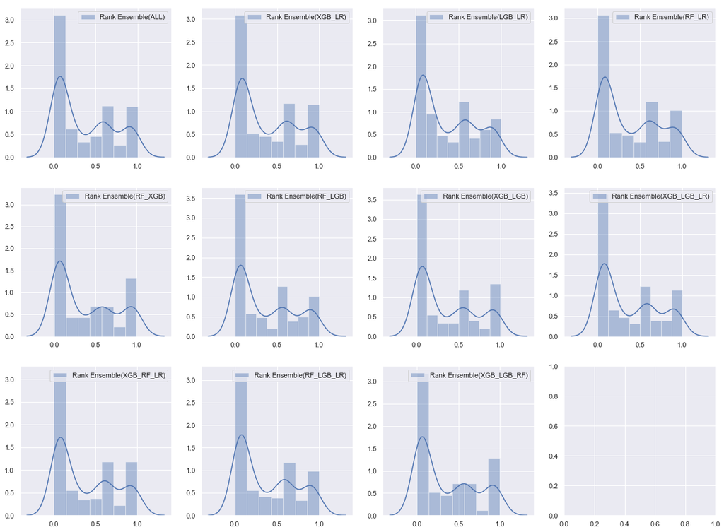

```python
en_probs = [en_rank, en_rank_xgb_lr, en_rank_lgb_lr, en_rank_rf_lr, en_rank_rf_xgb, en_rank_rf_lgb, en_rank_xgb_lgb,
            en_rank_xgb_lgb_lr, en_rank_xgb_rf_lr,en_rank_rf_lgb_lr, en_rank_xgb_lgb_rf]
en_names = ['Rank Ensemble(ALL)', 'Rank Ensemble(XGB_LR)', 'Rank Ensemble(LGB_LR)', 'Rank Ensemble(RF_LR)',
        'Rank Ensemble(RF_XGB)', 'Rank Ensemble(RF_LGB)', 'Rank Ensemble(XGB_LGB)', 'Rank Ensemble(XGB_LGB_LR)',
        'Rank Ensemble(XGB_RF_LR)', 'Rank Ensemble(RF_LGB_LR)', 'Rank Ensemble(XGB_LGB_RF)']
f, ax = plt.subplots(3,4, figsize=(20,15))
for i in range(len(en_probs)):
    sns.distplot(en_probs[i], label=en_names[i], ax=ax[i//4,i%4])
    ax[i//4,i%4].legend()
```

# Evaluation

**Train AUROC**

```python
auc_df = pd.DataFrame({'LR':lr_auc_list, 'RF':rf_auc_list, 'XGB':xgb_auc_list, 'LGB':lgb_auc_list})
auc_df.mean().reset_index().sort_values(by=0, ascending=False)
```

|  | index | 0 |
| --- | --- | --- |
| 3 | LGB | 0.882443 |
| 2 | XGB | 0.873593 |
| 0 | LR | 0.868808 |
| 1 | RF | 0.867327 |

# Save

```python
num = len(os.listdir('../submission/'))
print('num : ',num)
```

```
num :  6
```

```python
models = ['Logistic Regression','Random Forest','XGboost','LightGBM']
params = [lr_params, rf_params, xgb_params, lgb_params]
auc = [np.mean(lr_auc_list), np.mean(rf_auc_list), np.mean(xgb_auc_list), np.mean(lgb_auc_list)]
acc = [np.mean(lr_acc_list), np.mean(rf_acc_list), np.mean(xgb_acc_list), np.mean(lgb_acc_list)]
pd.DataFrame({'Model':models, 'Feature':[features]*len(models),'Params':params, 'AUC':auc, 'ACC':acc}).to_csv('../save_record/submit{}_record.csv'.format(num), index=False)
```

```python
probs.to_csv('../save_record/submit{}_probs.csv'.format(num), index=False)
```

# Submission

```python
submit = pd.read_csv('../dataset/gender_submission.csv')
submit.loc[:,'Survived'] = xgb_prediction
submit.head()
```

|  | PassengerId | Survived |
| --- | --- | --- |
| 0 | 892 | 0.199282 |
| 1 | 893 | 0.595891 |
| 2 | 894 | 0.169738 |
| 3 | 895 | 0.205489 |
| 4 | 896 | 0.631823 |

```python
select_model = 'xgb'
```

```python
submit.to_csv('../submission/submit{}({}).csv'.format(num,select_model), index=False)
```

# Load submission

```python
submit_files = os.listdir('../submission')
submit_en_probs = np.zeros(test.shape[0])
for file in submit_files[2:-1]:
    submit_i = pd.read_csv('../submission/{}'.format(file))
    submit_i = submit_i.sort_values(by='Survived')
    submit_i.loc[:,'ranking'] = np.arange(1,test.shape[0]+1)
    submit_i = submit_i.sort_values(by='PassengerId')

    submit_en_probs += submit_i.ranking / (len(submit_files)-3)
```

```python
submit = pd.read_csv('../dataset/gender_submission.csv')
submit.loc[:,'Survived'] = submit_en_probs
submit.head()
```

|  | PassengerId | Survived |
| --- | --- | --- |
| 0 | 892 | 34.00 |
| 1 | 893 | 294.25 |
| 2 | 894 | 5.50 |
| 3 | 895 | 82.75 |
| 4 | 896 | 288.75 |

```python
max_en = max(submit_en_probs)
min_en = min(submit_en_probs)
submit.Survived = submit.Survived.apply(lambda x: (x - min_en)/(max_en - min_en))
```

```python
select_model = 'ranking_en(submit1,2,3,4)'
submit.to_csv('../submission/{}.csv'.format(5,select_model), index=False)
```